# Understanding the Change-Score Clusters

Who Changed Their Views After Talking with an AI — and How?

Published

February 18, 2026

# Background: What Was the Study?

Tucker Carlson viewers (213 participants from two panels — PrimePanels and CloudResearch Connect) completed surveys before and after engaging in a structured, AI-delivered conversation that provided factual context about Israel-related topics. Participants rated Tucker Carlson’s credibility, their foreign policy views, and their attitudes toward Israel on 0–100 sliders, both before and after the conversation.

A **change score** (Δ = post − pre) was computed for each of the 20 outcome items per person. These 20 change scores were then submitted to k-means cluster analysis to identify groups of people who changed in similar ways — or didn’t change at all.

The silhouette criterion identified **k = 2 clusters** as the best-fitting solution.

# The Two Clusters

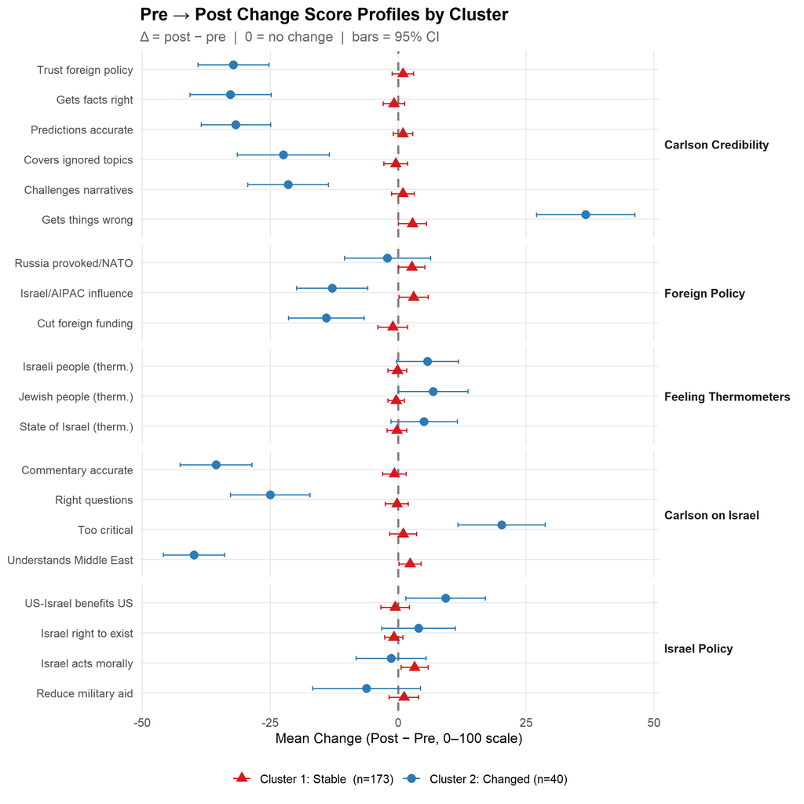

## Cluster 1 — “The Stable Majority” (n = 173, 81% of participants)

[figure not shown]

Figure 2: The Stable cluster’s change scores are indistinguishable from zero across every domain.

The defining characteristic of this cluster is **nothing happened**. Across all 20 items — Carlson credibility, foreign policy views, feeling thermometers toward Israel, perceptions of his Israel commentary, and Israel policy positions — this group’s average change score sits within a few points of zero in either direction.

This does not mean these participants were unengaged. It means that after the AI conversation, their measured attitudes were essentially the same as before. This is actually the most common outcome in political attitude research: a single exposure to counter-information, even a well-structured one, is generally insufficient to move deeply held political and media-credibility beliefs.

**Key takeaway:** The AI conversation had no detectable effect on the majority of participants.

## Cluster 2 — “The Changed Minority” (n = 40, 19% of participants)

This smaller cluster shows a coherent, multi-domain pattern of attitude change. Understanding it requires looking at *what changed* and *in what direction*.

### What changed — and in which direction

Table 1: Mean change scores for the Changed cluster (Cluster 2, n = 40). Items are grouped by domain. Negative = decreased after the AI conversation; positive = increased.

Changed Cluster (n = 40): Mean Δ per item

| Domain | Item | Mean Δ | Direction |
| --- | --- | --- | --- |
| Carlson Credibility | Trust foreign policy | -32.2 | ↓ Decreased |
|  | Gets facts right | -32.8 | ↓ Decreased |
|  | Predictions accurate | -31.7 | ↓ Decreased |
|  | Covers ignored topics | -22.4 | ↓ Decreased |
|  | Challenges narratives | -21.5 | ↓ Decreased |
|  | Gets things wrong | 36.6 | ↑ Increased |
| Foreign Policy | Russia provoked/NATO | -2.1 | ≈ Little change |
|  | Israel/AIPAC influence | -12.9 | ↓ Decreased |
|  | Cut foreign funding | -14.0 | ↓ Decreased |
| Feeling Thermometers | Israeli people (therm.) | 5.8 | ≈ Little change |
|  | Jewish people (therm.) | 6.9 | ≈ Little change |
|  | State of Israel (therm.) | 5.1 | ≈ Little change |
| Carlson on Israel | Commentary accurate | -35.6 | ↓ Decreased |
|  | Right questions | -25.0 | ↓ Decreased |
|  | Too critical | 20.2 | ↑ Increased |
|  | Understands Middle East | -39.9 | ↓ Decreased |
| Israel Policy | US-Israel benefits US | 9.3 | ≈ Little change |
|  | Israel right to exist | 4.0 | ≈ Little change |
|  | Israel acts morally | -1.4 | ≈ Little change |
|  | Reduce military aid | -6.2 | ≈ Little change |

Δ = post − pre. All items are 0–100 sliders except where noted. Items with |Δ| ≥ 10 are considered meaningful movement.

### The story told by the pattern

The changes are not random. They form a coherent narrative across three related shifts:

**1. Tucker Carlson lost credibility**

Five of the six credibility items dropped substantially (ranging roughly –20 to –35 points). Participants in this cluster came out of the AI conversation feeling that Carlson:

The sixth credibility item — “He often gets things *wrong*” — moved in the *opposite* direction (a large increase), which is fully consistent: if you believe he gets things wrong *more*, this reverse-coded item should go up. The credibility pattern is internally coherent.

**2. Views on Carlson’s Israel coverage shifted**

Two items measuring how participants see Carlson’s *specific* Israel commentary also dropped sharply:

- “His commentary on Israel is accurate and fair” — large decrease
- “He understands the Middle East better than most commentators” — the single largest decrease of any item

Meanwhile, “He is too critical of Israel” increased. This means participants in this cluster came to see Carlson as *less credible on Israel* and *more unfairly critical of Israel* at the same time — a nuanced shift suggesting the AI’s factual information reframed Carlson’s Israel coverage as both inaccurate *and* biased against Israel.

**3. Attitudes toward Israel warmed**

Feeling thermometers toward Israeli people, Jewish people, and the State of Israel all increased modestly. This suggests that reduced confidence in Carlson’s anti-Israel framing coincided with somewhat warmer feelings toward Israel itself. This is what would be expected if the AI conversation successfully provided factual context that countered a skeptical narrative: once the messenger’s credibility drops, the underlying attitudes can shift.

### A coherent persuasion sequence

The three shifts above are consistent with a single causal chain:

```
AI provides factual context
        ↓
Participants question Carlson's accuracy on Israel
        ↓
Carlson's credibility as a foreign-policy commentator falls
        ↓
His anti-Israel framing loses persuasive force
        ↓
Attitudes toward Israel become somewhat warmer
```

This is the classic **two-step persuasion model**: factual information first targets the *source’s credibility*, which then allows attitude change on the *topic* itself. The effect is not large, but it is patterned.

### Who is in the Changed cluster?

Table 2: Demographic comparison: Changed vs. Stable clusters

| Cluster | n | % Republican | % Democrat | % Ind./Other | % Conservative | % PrimePanels | Mean Age (Con.) |
| --- | --- | --- | --- | --- | --- | --- | --- |
| 1 (Stable) | 173 | 72% | 5% | 23% | 82% | 51% | 40.1 |
| 2 (Changed) | 40 | 82% | 8% | 10% | 65% | 82% | 53.7 |

Mean Age uses Connect numeric age only. Conservative = Very or Somewhat conservative.

**CautionCaution: Small n in the Changed Cluster**

With only n = 40 participants in the Changed cluster, demographic percentages are based on very small cell counts and should be interpreted with extreme caution. No reliable demographic profile of “who changes” can be drawn from a sample this size. The figures above are presented for descriptive purposes only.

# Profiles: Who Are These Groups?

Understanding the two clusters requires looking not just at *what changed* but at *who these people were* — both in terms of their attitudes before the AI conversation and their demographic backgrounds. This section addresses two diagnostic questions that help translate the clusters into a picture a general audience can understand.

## Were the Groups Already Attitudinally Different Before the Conversation?

**The most important diagnostic question:** did the people who changed their minds start out already different from those who didn’t? If the Changed cluster came in with lower Carlson credibility or already-warmer Israel attitudes, the AI conversation may have simply accelerated a shift that was already underway. If both clusters looked similar at baseline, the AI conversation was doing more of the genuine persuasive work.

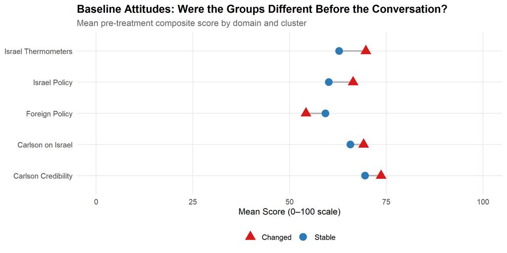

Figure 3: Mean pre-treatment score by domain for each cluster. Connecting lines show the gap between the two groups. Both clusters were recruited as Carlson fans — this shows how similar (or different) they looked before any treatment.

Table 3: Mean pre-treatment scores and ideology by cluster. Higher scores = more positive toward the domain. Ideology: 1 = Very liberal, 5 = Very conservative.

| Cluster | n | Carlson Credibility | Carlson on Israel | Foreign Policy | Israel Policy | Israel Thermometers | Ideology (1–5) |
| --- | --- | --- | --- | --- | --- | --- | --- |
| Changed | 40 | 73.7 | 69.1 | 54.2 | 66.4 | 69.7 | 3.83 |
| Stable | 173 | 69.5 | 65.7 | 59.3 | 60.2 | 62.8 | 4.17 |

All attitude scales: 0–100 composite means (average across domain items). Ideology: 1 = Very liberal … 5 = Very conservative.

**NoteWhat to look for**

- **Carlson Credibility (pre)**: If the Changed cluster started *lower*, they were already softer fans and the AI conversation finished the job. If the groups started similarly, the conversation genuinely moved people who began as true believers — a stronger result.
- **Israel Thermometers (pre)**: A lower starting temperature in the Changed cluster would suggest they had more room to warm up. A similar starting point would suggest the shift was driven by changed reasoning, not just ceiling/floor effects.
- **Ideology**: Both groups should lean conservative (they are Carlson fans). A more moderate Changed cluster would suggest persuadability correlates with ideological flexibility.

## Full Demographic Profile

Table 4: Demographic and engagement profile by cluster. All percentages based on small cell counts — treat as descriptive only.

| Cluster | n | % Republican | % Democrat | % Ind. / Other | % Conservative | % Moderate | % Liberal | % Female | % White | % Regular Carlson viewer | Mean age (Connect only) | % from PrimePanels |
| --- | --- | --- | --- | --- | --- | --- | --- | --- | --- | --- | --- | --- |
| Changed | 40 | 82% | 8% | 10% | 65% | 28% | 8% | 40% | 72% | 40% | 53.7 | 82% |
| Stable | 173 | 72% | 5% | 23% | 82% | 10% | 8% | 32% | 78% | 39% | 40.1 | 51% |

Regular viewer = watches every day or several times per week. Female and White are binary-coded from gender/sex and race/ethnicity columns. Mean age uses Connect panel-provided numeric age only.

**CautionCaution: Small cell counts**

With only n = 40 in the Changed cluster, none of the demographic percentages are statistically reliable. These are descriptive starting points for hypothesis generation, not confirmatory findings.

## Plain-Language Portraits

The cluster analysis identified two conceptually distinct types of viewer. Here is how to describe them to a general audience.

### The Stable 80%: “The Anchored Believer”

These viewers came into the study with a settled relationship with Tucker Carlson and left with exactly the same one. One AI conversation that challenged Carlson’s accuracy on Israel did nothing to change their views.

**What explains this?** Their trust in Carlson is not primarily a consumer-style judgment of his factual accuracy — it is closer to **identity and loyalty**. They trust him because he represents their values, their skepticism of mainstream institutions, and their way of seeing the world. Providing evidence that he got something wrong does not reach this kind of trust, because identity-based trust is not rooted in a running tally of accurate claims. It is more like asking a committed sports fan to abandon their team because the quarterback had a bad game. The logic does not land.

This is also the **normal outcome** in political persuasion research. Beliefs tied to group identity are among the most resistant to single-exposure interventions. This is not a failure of the intervention or a sign that these participants were inattentive — it is simply how deeply held political attitudes work.

> **In plain terms**: These are the true believers. Their view of Carlson is part of who they are politically. You will not change their minds with facts alone, and probably not with any single conversation.

### The Changed 20%: “The Evidence-Responsive Viewer”

This smaller group held broadly similar political views going into the study — also Carlson fans, also skeptical of Israel — but their credibility judgment of Carlson was more **information-contingent**. They trusted him, in part, because they believed he was getting things right. When the AI provided factual context suggesting he was not, they revised their assessment.

Think of the difference between two customers: one who gives a brand 5-star reviews out of loyalty no matter what, and one who starts with a favorable impression but revises it when they discover the brand has been misleading them. The Changed cluster represents the second type of viewer.

What this change is **not** is equally important: it is not a political conversion. These participants did not abandon their conservative politics or become Israel advocates. They became more skeptical of *one source* — Tucker Carlson — on *one topic* — Israel. Their warmth toward Israel increased modestly as a downstream consequence of reduced trust in an anti-Israel framing. That is a targeted and limited shift, not a worldview overhaul.

> **In plain terms**: These are the persuadable ones. They came in liking Carlson, but their trust was based partly on believing he was accurate. When shown evidence he wasn’t, they updated. They are not converts — they just care whether their sources tell the truth.

# Summary

Table 5: Summary: the two change clusters

|  | Stable Cluster | Changed Cluster |
| --- | --- | --- |
| **Size** | n = 173 (81% of sample) | n = 40 (19% of sample) |
| **Core finding** | No detectable change on any of the 20 items | Coherent multi-domain shift: Carlson credibility ↓, Israel attitudes ↑ |
| **Carlson credibility** | No change | Large decreases on 5 of 6 items (–20 to –35 points) |
| **Carlson on Israel** | No change | Commentary accuracy ↓; 'Too critical' ↑; Understands Middle East ↓ |
| **Israel thermometers** | No change | Modest increases toward Israeli people, Jewish people, State of Israel |
| **Foreign policy views** | No change | Some decreases (AIPAC influence, cut funding); modest movement |
| **Israel policy positions** | No change | Mixed; some movement toward more pro-Israel positions |
| **Interpretation** | The AI conversation did not move this group's attitudes | Lost trust in Carlson as an accurate source → warmer Israel attitudes |

The central finding from the change-cluster analysis is that **the AI conversation produced a meaningful attitude shift in a minority of participants** (19%), while the large majority showed no movement. The minority who changed did so in a patterned, theoretically coherent way — losing confidence in Tucker Carlson’s accuracy and fairness while simultaneously warming toward Israel. This pattern is consistent with a source-credibility mechanism: once the messenger is discredited, the message loses its grip.

# What to Investigate Next

These pilot results suggest several productive questions for a larger study:

1. **What predicts persuadability?** With only n = 40 in the Changed cluster, we cannot reliably identify demographic or psychological predictors of who changes. A full-scale study with n ≥ 500 would allow meaningful subgroup analysis.
2. **Does credibility loss persist?** The pre–post design captures immediate effects. A follow-up measurement (e.g., two weeks later) would test whether the credibility decrease and warmer Israel attitudes are durable or snap back.
3. **Is the effect driven by conversation content or mere exposure?** A control condition (e.g., participants who complete both surveys but have a neutral AI conversation) would allow causal attribution.
4. **Does the same pattern hold across different topics?** The intervention targeted Israel specifically. Whether a similar credibility-then-attitude pathway applies to other Carlson topics (Russia, immigration, vaccines) is an open question.

*Report generated from the combined PrimePanels + Connect dataset (n = 213 completed). Analysis performed using R with tidyverse and cluster packages.*